# rnaseq-splice report: ENCODE U2AF2 shRNA knockdown in K562 and HepG2 (positive control)

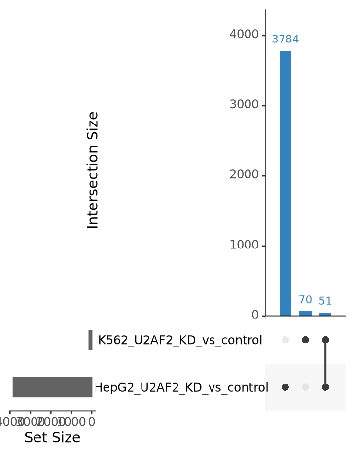

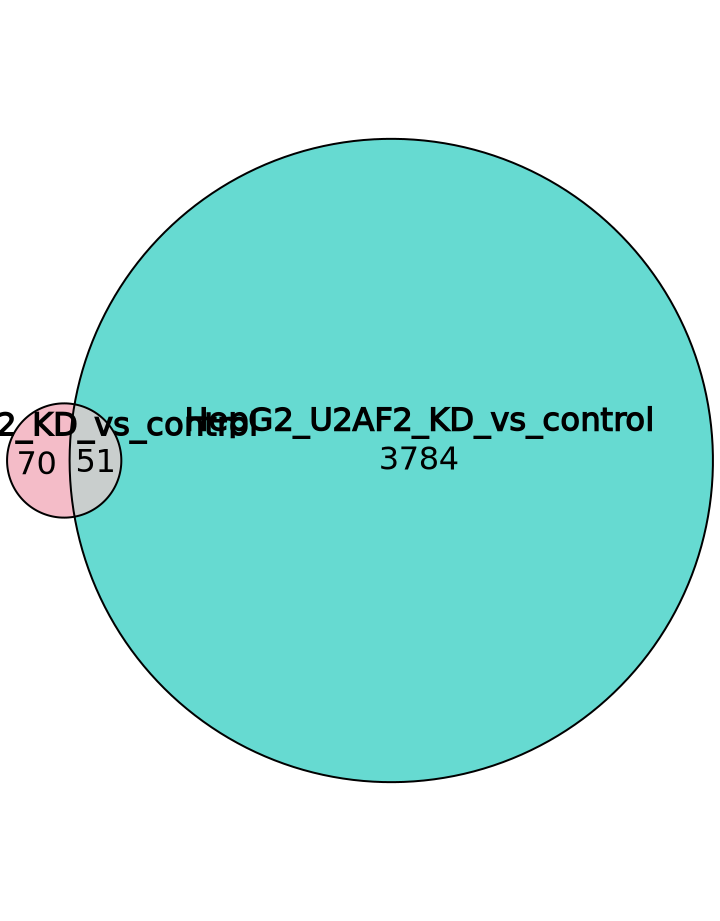

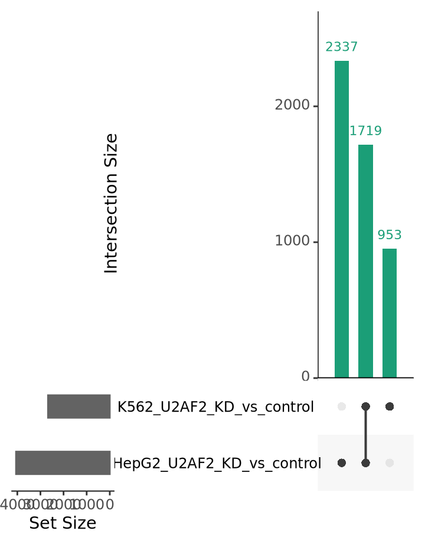

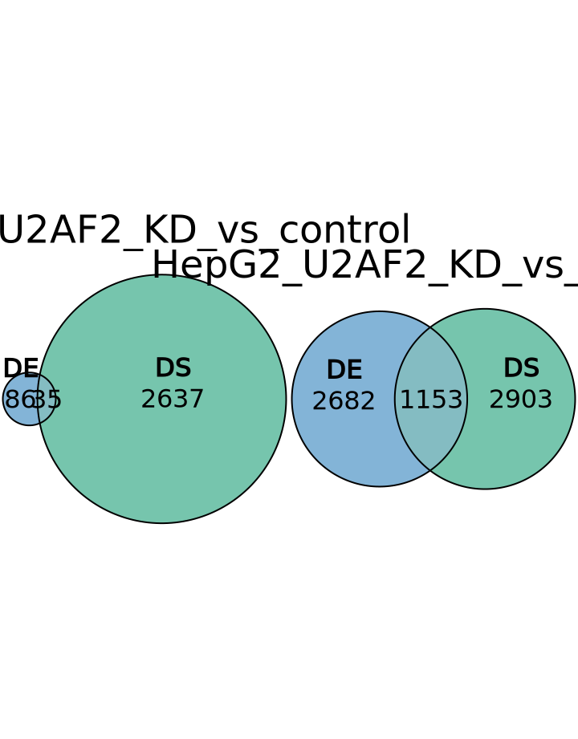

# Overview

### Samples

8

### Conditions

4

### Contrasts

2

### Significance

0.01 / 0.01

### About this report

**Project:** encode_U2AF2_K562_HepG2

**Generated:** 2026-10-26 14:01 PDT

**Results folder:** `results`

Differential expression from limma/voom and differential splicing from rMATS, both computed by the rnaseq-splice pipeline for every contrast below. Differentially expressed genes: limma adjusted p-value (BH) < 0.01, no fold-change cut-off . Differentially spliced events: rMATS FDR < 0.01, no ΔPSI cut-off . **No fold-change or ΔPSI cut-off is applied.**

**Direction:** logFC > 0 means higher expression in the treatment group; ΔPSI > 0 means higher exon inclusion in the treatment group.

### Contrasts

| Contrast | Treatment | Control | n treatment | n control | DE genes | DS events |
| --- | --- | --- | --- | --- | --- | --- |
| K562_U2AF2_KD_vs_control | K562_U2AF2_KD | K562_control | 2 | 2 | 121 | 5220 |
| HepG2_U2AF2_KD_vs_control | HepG2_U2AF2_KD | HepG2_control | 2 | 2 | 3835 | 8600 |

### Samples

| sample | condition |
| --- | --- |
| K562_U2AF2_KD_rep1 | K562_U2AF2_KD |
| K562_U2AF2_KD_rep2 | K562_U2AF2_KD |
| K562_control_rep1 | K562_control |
| K562_control_rep2 | K562_control |
| HepG2_U2AF2_KD_rep1 | HepG2_U2AF2_KD |
| HepG2_U2AF2_KD_rep2 | HepG2_U2AF2_KD |
| HepG2_control_rep1 | HepG2_control |
| HepG2_control_rep2 | HepG2_control |

# QC

### Reads per sample (STAR)

[interactive chart not shown]

### Mapping rate

[interactive chart not shown]

### QC summary table

| sample | condition | total_reads | uniquely_mapped | uniquely_mapped_pc | multimapped | duplication_pc |
| --- | --- | --- | --- | --- | --- | --- |
| HepG2_control_rep1 | HepG2_control | 26916826 | 24893447 | 92.48 | 1343035 | 53.9397 |
| HepG2_control_rep2 | HepG2_control | 30967927 | 29207145 | 94.31 | 1434161 | 60.12650000000001 |
| HepG2_U2AF2_KD_rep1 | HepG2_U2AF2_KD | 55214946 | 51246859 | 92.81 | 3356364 | 56.4866 |
| HepG2_U2AF2_KD_rep2 | HepG2_U2AF2_KD | 45570451 | 42142973 | 92.48 | 2871298 | 58.01070000000001 |
| K562_control_rep1 | K562_control | 24438423 | 22551718 | 92.28 | 1550969 | 19.9792 |
| K562_control_rep2 | K562_control | 28450078 | 26458035 | 93 | 1607043 | 20.8704 |
| K562_U2AF2_KD_rep1 | K562_U2AF2_KD | 24598729 | 22894444 | 93.07 | 1408388 | 20.0729 |
| K562_U2AF2_KD_rep2 | K562_U2AF2_KD | 23315487 | 21682687 | 93 | 1318485 | 19.9045 |

# Sample structure

### PCA (voom log-CPM, 500 most variable genes)

[interactive chart not shown]

### Sample correlation (Pearson, voom log-CPM)

[interactive chart not shown]

### Variance explained

[interactive chart not shown]

# DE summary

### DE genes per contrast (FDR < 0.01, no fold-change cut-off)

[interactive chart not shown]

### Summary table

| contrast | Up | Down | Total | tested | % of tested |
| --- | --- | --- | --- | --- | --- |
| K562_U2AF2_KD_vs_control | 77 | 44 | 121 | 17672 | 0.7 |
| HepG2_U2AF2_KD_vs_control | 2042 | 1793 | 3835 | 17672 | 21.7 |

### Overlap of DE genes between contrasts (UpSet)

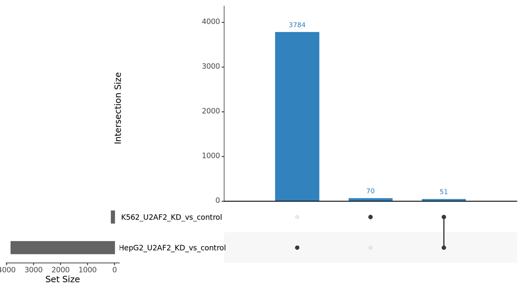

### Overlap (Euler diagram)

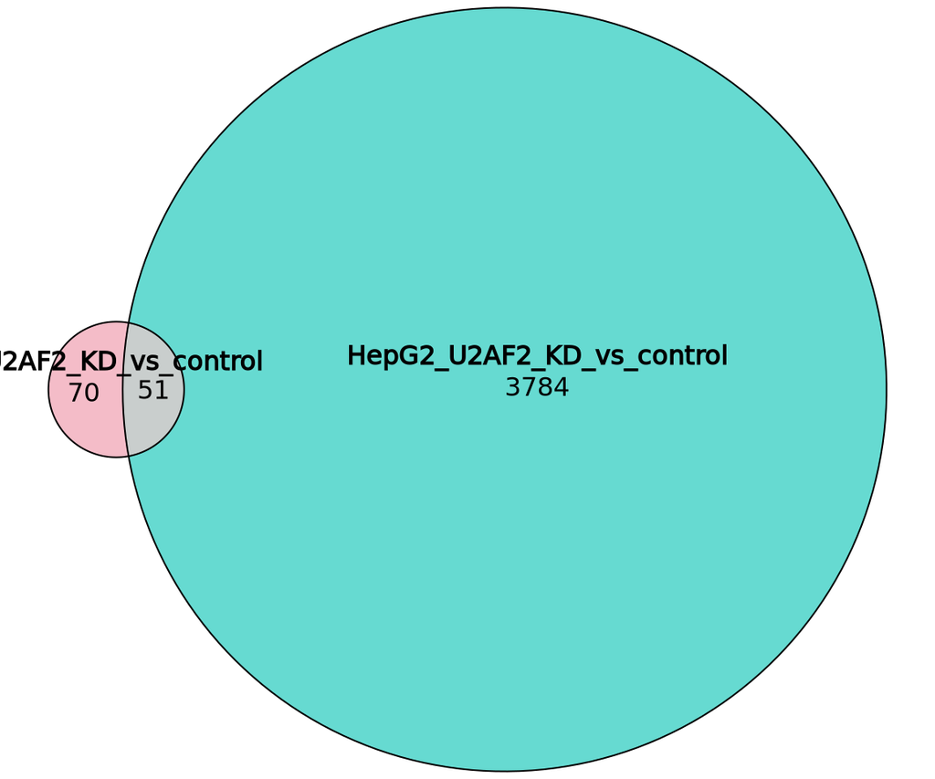

# K562_U2AF2_KD_vs_control

### Up in K562_U2AF2_KD vs K562_control

77

### Down in K562_U2AF2_KD vs K562_control

44

### Genes tested

17,672

### Volcano plot (FDR < 0.01, no fold-change cut-off — all 121 significant + random 2,000 of 17,551 non-significant shown)

[interactive chart not shown]

### MA plot — all 121 significant + random 2,000 of 17,551 non-significant shown

[interactive chart not shown]

### Differentially expressed genes (FDR < 0.01, no fold-change cut-off)

Also saved as K562_U2AF2_KD_vs_control_DE_genes.tsv

| gene_id | gene_name | direction | logFC | AveExpr | t | P.Value | FDR |
| --- | --- | --- | --- | --- | --- | --- | --- |
| ENSG00000238122 | AL359258.1 | Up | 8.72173049300018 | -3.36025165870006 | 22.3434112682219 | 3.92757310137394e-08 | 0.000510508272890679 |
| ENSG00000239435 | KCNMB3P1 | Up | 7.23634353233418 | -3.3963745555326 | 21.2066063572969 | 5.77759475883521e-08 | 0.000510508272890679 |
| ENSG00000120738 | EGR1 | Up | 3.27126193211322 | 6.20502592612631 | 19.0986251905244 | 1.25032730223066e-07 | 0.000736526136167341 |
| ENSG00000073910 | FRY | Up | 6.47424886750474 | 1.16543067249099 | 17.4472005598731 | 2.43012387408875e-07 | 0.000805363300647326 |
| ENSG00000157404 | KIT | Up | 3.48469761137674 | -1.28197360421027 | 17.1700830005109 | 2.73281860000617e-07 | 0.000805363300647326 |
| ENSG00000255717 | SNHG1 | Up | 2.07208478602922 | 7.8965128030919 | 17.1687529952146 | 2.73437064502261e-07 | 0.000805363300647326 |
| ENSG00000123496 | IL13RA2 | Up | 5.92726028120915 | -4.1774707124798 | 15.1174527224505 | 6.92859115747699e-07 | 0.00146053167190074 |
| ENSG00000168754 | FAM178B | Down | -2.57762989096734 | -0.118291549828219 | -14.9951685442873 | 7.35067392764683e-07 | 0.00146053167190074 |
| ENSG00000182752 | PAPPA | Up | 3.42558480797482 | 1.5096457554237 | 14.9708040541069 | 7.43819887228763e-07 | 0.00146053167190074 |
| ENSG00000260802 | SERTM2 | Up | 5.27331154736045 | -4.34135942531005 | 13.5854146620045 | 1.50490892157497e-06 | 0.00241770458746117 |

[output cut: 111 more lines]

### Top 50 DE genes (row z-scores of voom log-CPM)

[interactive chart not shown]

# HepG2_U2AF2_KD_vs_control

### Up in HepG2_U2AF2_KD vs HepG2_control

2,042

### Down in HepG2_U2AF2_KD vs HepG2_control

1,793

### Genes tested

17,672

### Volcano plot (FDR < 0.01, no fold-change cut-off — all 3,835 significant + random 2,000 of 13,837 non-significant shown)

[interactive chart not shown]

### MA plot — all 3,835 significant + random 2,000 of 13,837 non-significant shown

[interactive chart not shown]

### Differentially expressed genes (FDR < 0.01, no fold-change cut-off)

Also saved as HepG2_U2AF2_KD_vs_control_DE_genes.tsv

| gene_id | gene_name | direction | logFC | AveExpr | t | P.Value | FDR |
| --- | --- | --- | --- | --- | --- | --- | --- |
| ENSG00000067082 | KLF6 | Up | 2.0092416363381 | 6.9835820629434 | 18.423504677691 | 1.62927718828277e-07 | 7.45300451456087e-05 |
| ENSG00000080986 | NDC80 | Down | -3.44095442802339 | 5.26539290816865 | -19.2022474594968 | 1.20150225738781e-07 | 7.45300451456087e-05 |
| ENSG00000088325 | TPX2 | Down | -2.38197784611708 | 7.94765772979297 | -21.6585485401951 | 4.94407940689665e-08 | 7.45300451456087e-05 |
| ENSG00000090889 | KIF4A | Down | -3.45264124125104 | 5.46771871882905 | -21.2328593641576 | 5.72503992636704e-08 | 7.45300451456087e-05 |
| ENSG00000112984 | KIF20A | Down | -4.04719509344789 | 5.55159230327357 | -19.0461963681914 | 1.27588314202196e-07 | 7.45300451456087e-05 |
| ENSG00000113368 | LMNB1 | Down | -2.62588686204195 | 6.81037607080444 | -18.9254981544312 | 1.33699294646421e-07 | 7.45300451456087e-05 |
| ENSG00000116679 | IVNS1ABP | Down | -2.29247012093349 | 6.2723965551745 | -19.2595868189403 | 1.17541377271284e-07 | 7.45300451456087e-05 |
| ENSG00000117650 | NEK2 | Down | -3.03926586447431 | 5.67567864190349 | -20.1353721515878 | 8.47000081743574e-08 | 7.45300451456087e-05 |
| ENSG00000118193 | KIF14 | Down | -4.27035993301513 | 5.19921904052013 | -19.350362549111 | 1.13541162174359e-07 | 7.45300451456087e-05 |
| ENSG00000118523 | CCN2 | Down | -1.87982157648243 | 1.52198978487847 | -20.3399074185895 | 7.86160322036237e-08 | 7.45300451456087e-05 |

[output cut: 3825 more lines]

### Top 50 DE genes (row z-scores of voom log-CPM)

[interactive chart not shown]

# Splicing summary

### Significant splicing events by type (FDR < 0.01, no ΔPSI cut-off)

[interactive chart not shown]

### Direction of change (treatment vs control)

[interactive chart not shown]

### Events tested and significant, per contrast and type

| contrast | event_type | tested | Higher inclusion | Lower inclusion | significant |
| --- | --- | --- | --- | --- | --- |
| K562_U2AF2_KD_vs_control | SE (Skipped exon) | 38002 | 528 | 2966 | 3494 |
| K562_U2AF2_KD_vs_control | MXE (Mutually exclusive exons) | 6491 | 254 | 274 | 528 |
| K562_U2AF2_KD_vs_control | A3SS (Alternative 3' splice site) | 4407 | 261 | 135 | 396 |
| K562_U2AF2_KD_vs_control | A5SS (Alternative 5' splice site) | 2906 | 125 | 85 | 210 |
| K562_U2AF2_KD_vs_control | RI (Retained intron) | 3263 | 482 | 110 | 592 |
| HepG2_U2AF2_KD_vs_control | SE (Skipped exon) | 35000 | 916 | 4450 | 5366 |
| HepG2_U2AF2_KD_vs_control | MXE (Mutually exclusive exons) | 5657 | 772 | 559 | 1331 |
| HepG2_U2AF2_KD_vs_control | A3SS (Alternative 3' splice site) | 4227 | 362 | 261 | 623 |
| HepG2_U2AF2_KD_vs_control | A5SS (Alternative 5' splice site) | 2598 | 159 | 178 | 337 |
| HepG2_U2AF2_KD_vs_control | RI (Retained intron) | 3230 | 785 | 158 | 943 |

### Overlap of differentially spliced genes between contrasts (UpSet)

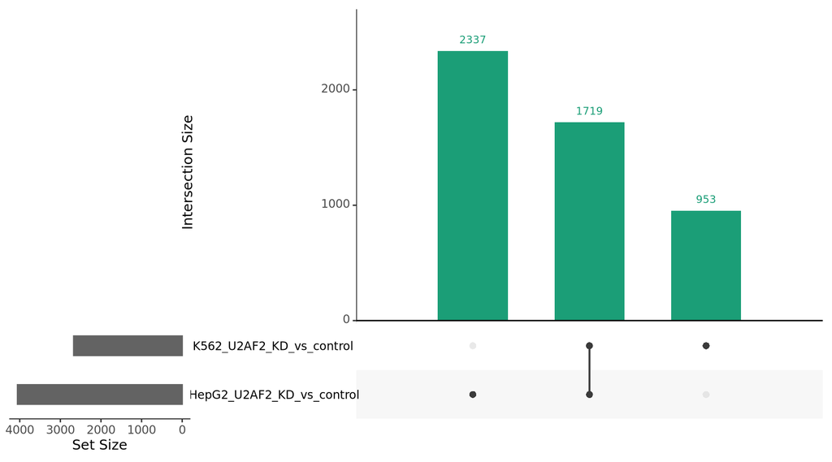

# K562_U2AF2_KD_vs_control

### Higher inclusion in K562_U2AF2_KD

1,650

### Lower inclusion in K562_U2AF2_KD

3,570

### Genes with a significant event

2,672

### Events tested

55,069

### ΔPSI volcano (FDR < 0.01, no ΔPSI cut-off — all 5,220 significant + random 2,000 of 49,849 non-significant shown)

[interactive chart not shown]

### ΔPSI of significant events by type

[interactive chart not shown]

### Significant events by type and direction (FDR < 0.01, no ΔPSI cut-off)

[interactive chart not shown]

### Top 15 significant events per type: PSI per sample (row z-scores of PSI; hover for PSI)

[interactive chart not shown]

### Significant splicing events (FDR < 0.01, no ΔPSI cut-off)

Showing the 5,000 rows with the lowest FDR out of 5,220. Full table: K562_U2AF2_KD_vs_control_DS_events.tsv

| event_id | event_type | gene_id | gene_name | location | PSI_treatment | PSI_control | dPSI | PValue | FDR | junction_reads |
| --- | --- | --- | --- | --- | --- | --- | --- | --- | --- | --- |
| SE_68174 | SE | ENSG00000130227 | XPO7 | chr8:21971876-21971968 (+) | 0.185 | 0.9395 | -0.754 | 0 | 0 | 626 |
| SE_71067 | SE | ENSG00000119397 | CNTRL | chr9:121157740-121157880 (+) | 0.2305 | 0.9795 | -0.749 | 0 | 0 | 142 |
| SE_69677 | SE | ENSG00000176731 | RBIS | chr8:85214921-85215037 (-) | 0.1495 | 0.8815 | -0.732 | 0 | 0 | 3501 |
| SE_25049 | SE | ENSG00000123737 | EXOSC9 | chr4:121816144-121816194 (+) | 0.045 | 0.7385 | -0.694 | 0 | 0 | 237 |
| SE_53938 | SE | ENSG00000172493 | AFF1 | chr4:87132271-87132408 (+) | 0.326 | 1 | -0.674 | 0 | 0 | 177 |
| SE_51937 | SE | ENSG00000163006 | CCDC138 | chr2:108788032-108788089 (+) | 0.248 | 0.894 | -0.646 | 0 | 0 | 178 |
| SE_63014 | SE | ENSG00000116679 | IVNS1ABP | chr1:185306485-185306625 (-) | 0.737 | 0.097 | 0.64 | 0 | 0 | 1003 |
| A3SS_6768 | A3SS | ENSG00000055609 | KMT2C | chr7:long 152156205-152156343 \| short 152156205-152156274 (-) | 0.191 | 0.827 | -0.636 | 0 | 0 | 324 |
| SE_34402 | SE | ENSG00000134759 | ELP2 | chr18:36138795-36138872 (+) | 0.3185 | 0.9504999999999999 | -0.632 | 0 | 0 | 275 |
| SE_47447 | SE | ENSG00000153207 | AHCTF1 | chr1:246843795-246843928 (-) | 0.2805 | 0.903 | -0.623 | 0 | 0 | 507 |

[output cut: 4990 more lines]

# HepG2_U2AF2_KD_vs_control

### Higher inclusion in HepG2_U2AF2_KD

2,994

### Lower inclusion in HepG2_U2AF2_KD

5,606

### Genes with a significant event

4,056

### Events tested

50,712

### ΔPSI volcano (FDR < 0.01, no ΔPSI cut-off — all 8,600 significant + random 2,000 of 42,112 non-significant shown)

[interactive chart not shown]

### ΔPSI of significant events by type

[interactive chart not shown]

### Significant events by type and direction (FDR < 0.01, no ΔPSI cut-off)

[interactive chart not shown]

### Top 15 significant events per type: PSI per sample (row z-scores of PSI; hover for PSI)

[interactive chart not shown]

### Significant splicing events (FDR < 0.01, no ΔPSI cut-off)

Showing the 5,000 rows with the lowest FDR out of 8,600. Full table: HepG2_U2AF2_KD_vs_control_DS_events.tsv

| event_id | event_type | gene_id | gene_name | location | PSI_treatment | PSI_control | dPSI | PValue | FDR | junction_reads |
| --- | --- | --- | --- | --- | --- | --- | --- | --- | --- | --- |
| SE_53855 | SE | ENSG00000135976 | ANKRD36 | chr2:97142763-97142835 (+) | 0.067 | 1 | -0.933 | 0 | 0 | 66 |
| SE_42648 | SE | ENSG00000158411 | MITD1 | chr2:99171343-99171429 (-) | 0.1395 | 0.9744999999999999 | -0.835 | 0 | 0 | 547 |
| SE_11025 | SE | ENSG00000103197 | TSC2 | chr16:2077598-2077726 (+) | 1 | 0.1875 | 0.812 | 0 | 0 | 196 |
| SE_57125 | SE | ENSG00000079819 | EPB41L2 | chr6:130870328-130870381 (-) | 0.9485 | 0.156 | 0.792 | 0 | 0 | 374 |
| SE_12188 | SE | ENSG00000089195 | TRMT6 | chr20:5941243-5941345 (-) | 0.2305 | 1 | -0.77 | 0 | 0 | 307 |
| SE_16344 | SE | ENSG00000112640 | PPP2R5D | chr6:43008693-43008746 (+) | 0.2185 | 0.986 | -0.767 | 0 | 0 | 379 |
| SE_61995 | SE | ENSG00000116679 | IVNS1ABP | chr1:185306485-185306625 (-) | 0.8805000000000001 | 0.119 | 0.762 | 0 | 0 | 296 |
| RI_1522 | RI | ENSG00000140365 | COMMD4 | chr15:75338134-75338354 (+) | 0.847 | 0.09799999999999999 | 0.749 | 0 | 0 | 187 |
| SE_22994 | SE | ENSG00000204842 | ATXN2 | chr12:111552906-111552977 (-) | 0.2305 | 0.9735 | -0.743 | 0 | 0 | 363 |
| SE_79170 | SE | ENSG00000111319 | SCNN1A | chr12:6349164-6349221 (-) | 0.1925 | 0.9335 | -0.741 | 0 | 0 | 291 |

[output cut: 4990 more lines]

# DE × splicing

### Genes that are differentially expressed and/or spliced

[interactive chart not shown]

### Euler diagrams (DE genes vs DS genes)

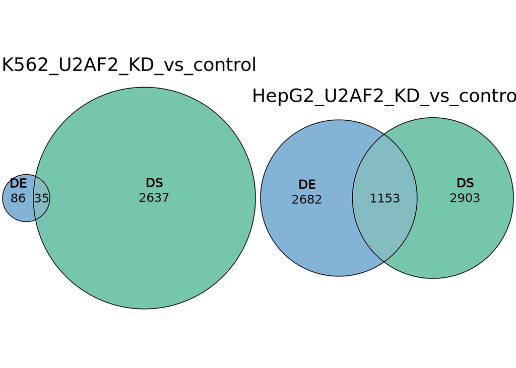

### Genes both differentially expressed and differentially spliced

Also saved as de_and_ds_genes.tsv

| contrast | gene_id | gene_name | logFC | DE_FDR | sig_events | event_types | dPSI_largest | min_event_FDR |
| --- | --- | --- | --- | --- | --- | --- | --- | --- |
| HepG2_U2AF2_KD_vs_control | ENSG00000088325 | TPX2 | -2.38197784611708 | 7.45300451456087e-05 | 1 | SE | -0.162 | 3.05636890519235e-10 |
| HepG2_U2AF2_KD_vs_control | ENSG00000116679 | IVNS1ABP | -2.29247012093349 | 7.45300451456087e-05 | 1 | SE | 0.762 | 0 |
| HepG2_U2AF2_KD_vs_control | ENSG00000126787 | DLGAP5 | -3.22396982125975 | 7.45300451456087e-05 | 1 | SE | -0.124 | 0.00138894753571023 |
| HepG2_U2AF2_KD_vs_control | ENSG00000131747 | TOP2A | -3.43038731934314 | 7.45300451456087e-05 | 1 | MXE | -0.176 | 0.000269667978805089 |
| HepG2_U2AF2_KD_vs_control | ENSG00000137807 | KIF23 | -2.62008142692936 | 7.45300451456087e-05 | 2 | MXE, SE | -0.233 | 1.0101188404256e-12 |
| HepG2_U2AF2_KD_vs_control | ENSG00000138668 | HNRNPD | -2.41325532781599 | 7.45300451456087e-05 | 5 | MXE, SE | 0.66 | 0 |
| HepG2_U2AF2_KD_vs_control | ENSG00000145386 | CCNA2 | -3.29595601031988 | 7.45300451456087e-05 | 1 | MXE | -0.162 | 5.08680330354954e-05 |
| HepG2_U2AF2_KD_vs_control | ENSG00000146918 | NCAPG2 | -2.40640813346133 | 7.45300451456087e-05 | 1 | SE | 0.171 | 0.00125684596712958 |
| HepG2_U2AF2_KD_vs_control | ENSG00000163110 | PDLIM5 | 2.00499078734076 | 7.45300451456087e-05 | 1 | SE | -0.109 | 0.000330696452349874 |
| HepG2_U2AF2_KD_vs_control | ENSG00000171552 | BCL2L1 | 1.82959797805142 | 7.45300451456087e-05 | 1 | SE | 0.049 | 2.50382081946465e-10 |

[output cut: 1178 more lines]

# Across contrasts

### DE genes per contrast (FDR < 0.01, no fold-change cut-off)

[interactive chart not shown]

### Differentially spliced events per contrast (FDR < 0.01, no ΔPSI cut-off)

[interactive chart not shown]

### Genes significant in how many contrasts

[interactive chart not shown]

### Top 50 DE genes across contrasts: log2 fold change (dot = significant; genes significant in ≥1 contrast, lowest FDR first; rows clustered by Euclidean distance)

[interactive chart not shown]

### Top 50 splicing events across contrasts: ΔPSI (dot = significant; grey = not tested; rows clustered by Euclidean distance)

[interactive chart not shown]

### Genes differentially expressed in at least one contrast: log2FC and FDR per contrast

Also saved as across_contrasts_DE_genes.tsv

| gene_id | gene_name | n_sig_contrasts | min_FDR | logFC_K562_U2AF2_KD_vs_control | logFC_HepG2_U2AF2_KD_vs_control | FDR_K562_U2AF2_KD_vs_control | FDR_HepG2_U2AF2_KD_vs_control |
| --- | --- | --- | --- | --- | --- | --- | --- |
| ENSG00000259040 | BLOC1S5-TXNDC5 | 1 | 7.45300451456087e-05 | 0.360593812009561 | -10.9668238414258 | 0.295641699800251 | 7.45300451456087e-05 |
| ENSG00000273003 | ARL2-SNX15 | 1 | 7.45300451456087e-05 | -0.357504037655313 | -9.81896893289587 | 0.504141049204439 | 7.45300451456087e-05 |
| ENSG00000284057 | AP001273.2 | 1 | 7.45300451456087e-05 | 0.459117002103124 | 8.49330083825475 | 0.304608550981281 | 7.45300451456087e-05 |
| ENSG00000285508 | AL034430.1 | 1 | 7.45300451456087e-05 | -1.55625546570185 | -8.27273234394754 | 0.0245812202131185 | 7.45300451456087e-05 |
| ENSG00000258830 | AC137834.1 | 1 | 7.45300451456087e-05 | 0.287074923954992 | 8.09649697273429 | 0.759313566485723 | 7.45300451456087e-05 |
| ENSG00000269693 | AC010422.6 | 1 | 7.45300451456087e-05 | 0.287074923954993 | 7.14771135749413 | 0.760549246852825 | 7.45300451456087e-05 |
| ENSG00000273217 | AC008695.1 | 1 | 7.45300451456087e-05 | 0.287074923954992 | 6.99135680140259 | 0.757776341587252 | 7.45300451456087e-05 |
| ENSG00000270681 | AC095055.1 | 2 | 7.45300451456087e-05 | 2.48267649852488 | 6.49223684299601 | 0.00894320436800916 | 7.45300451456087e-05 |
| ENSG00000176134 | AL445665.1 | 1 | 7.45300451456087e-05 | 0.287074923954993 | 4.92597358170349 | 0.775133281845778 | 7.45300451456087e-05 |
| ENSG00000152253 | SPC25 | 1 | 7.45300451456087e-05 | -1.11917043872521 | -4.76856218789139 | 0.0143877444875145 | 7.45300451456087e-05 |

[output cut: 3895 more lines]

### Splicing events significant in at least one contrast: ΔPSI and FDR per contrast

Showing the 5,000 rows with the lowest FDR out of 12,012. Full table: across_contrasts_DS_events.tsv

| event_type | gene_id | gene_name | location | n_sig_contrasts | n_tested_contrasts | min_FDR | dPSI_K562_U2AF2_KD_vs_control | dPSI_HepG2_U2AF2_KD_vs_control | FDR_K562_U2AF2_KD_vs_control | FDR_HepG2_U2AF2_KD_vs_control |
| --- | --- | --- | --- | --- | --- | --- | --- | --- | --- | --- |
| SE | ENSG00000135976 | ANKRD36 | chr2:97142763-97142835 (+) | 1 | 2 | 0 | -0.161 | -0.933 | 0.841061492776136 | 0 |
| SE | ENSG00000158411 | MITD1 | chr2:99171343-99171429 (-) | 2 | 2 | 0 | -0.611 | -0.835 | 0 | 0 |
| SE | ENSG00000103197 | TSC2 | chr16:2077598-2077726 (+) | 2 | 2 | 0 | 0.46 | 0.812 | 1.73025419242896e-05 | 0 |
| SE | ENSG00000079819 | EPB41L2 | chr6:130870328-130870381 (-) | 1 | 1 | 0 |  | 0.792 |  | 0 |
| SE | ENSG00000089195 | TRMT6 | chr20:5941243-5941345 (-) | 2 | 2 | 0 | -0.42 | -0.77 | 5.44112443210383e-05 | 0 |
| SE | ENSG00000112640 | PPP2R5D | chr6:43008693-43008746 (+) | 2 | 2 | 0 | -0.525 | -0.767 | 0 | 0 |
| SE | ENSG00000116679 | IVNS1ABP | chr1:185306485-185306625 (-) | 2 | 2 | 0 | 0.64 | 0.762 | 0 | 0 |
| SE | ENSG00000130227 | XPO7 | chr8:21971876-21971968 (+) | 2 | 2 | 0 | -0.754 | -0.652 | 0 | 3.7839522515595e-09 |
| RI | ENSG00000140365 | COMMD4 | chr15:75338134-75338354 (+) | 2 | 2 | 0 | 0.5 | 0.749 | 6.20699512986875e-09 | 0 |
| SE | ENSG00000119397 | CNTRL | chr9:121157740-121157880 (+) | 1 | 1 | 0 | -0.749 |  | 0 |  |

[output cut: 4990 more lines]

# Summary

### Gene sets regulated by expression (preranked GSEA, FDR < 0.05)

[interactive chart not shown]

### Gene sets over-represented among spliced genes (FDR < 0.05)

[interactive chart not shown]

### Gene sets regulated by expression, all contrasts (FDR < 0.05)

Also saved as gsea_expression_significant.tsv

| contrast | pathway | collection | direction | NES | padj | size | leading_edge_n | leading_edge |
| --- | --- | --- | --- | --- | --- | --- | --- | --- |
| K562_U2AF2_KD_vs_control | HALLMARK_TNFA_SIGNALING_VIA_NFKB | h.all.v2026.2.Hs.symbols | Up | 2.57785153158166 | 5.09455529262583e-14 | 174 | 77 | EGR1;PHLDA1;SERPINB2;EGR3;IL6ST;CCRL2;SAT1;CD44;IL7R;IL1A;TNFAIP3;FOSL2;SERPINE1;CCL2;RELA; … (77 genes) |
| K562_U2AF2_KD_vs_control | HALLMARK_OXIDATIVE_PHOSPHORYLATION | h.all.v2026.2.Hs.symbols | Down | -2.26121594966438 | 2.02786844799161e-09 | 199 | 72 | PHB2;DLD;BCKDHA;MDH1;ATP6V1H;ALDH6A1;ATP5ME;GOT2;GPX4;MRPL11;AIFM1;ECH1;ACO2;SLC25A11;ATP5MC1; … (72 genes) |
| K562_U2AF2_KD_vs_control | HALLMARK_ADIPOGENESIS | h.all.v2026.2.Hs.symbols | Down | -2.06328532770541 | 3.60950450327815e-06 | 183 | 69 | CAVIN2;ACLY;STOM;EPHX2;DLD;BCKDHA;ELMOD3;STAT5A;SNCG;ANGPT1;MCCC1;TALDO1;LPL;UCP2;CAVIN1; … (69 genes) |
| K562_U2AF2_KD_vs_control | KEGG_GLYCOLYSIS_GLUCONEOGENESIS | c2.cp.kegg_legacy.v2026.2.Hs.symbols | Down | -2.28727535084322 | 6.50286356662156e-05 | 42 | 23 | HK2;PKLR;DLD;ADH5;PFKM;ALDOA;PDHB;PGM2;ENO2;PGAM1;DLAT;PDHA1;GPI;PGK1;ALDH3A2; … (23 genes) |
| K562_U2AF2_KD_vs_control | KEGG_CYTOKINE_CYTOKINE_RECEPTOR_INTERACTION | c2.cp.kegg_legacy.v2026.2.Hs.symbols | Up | 2.10702262554863 | 6.50286356662156e-05 | 128 | 44 | KIT;FLT1;IL6ST;IL7R;IL1A;ACVR1;IL18RAP;CCL2;TNFRSF21;IL4R;TNFRSF9;TNFSF4;KITLG;CCR7;IL17B; … (44 genes) |
| K562_U2AF2_KD_vs_control | REACTOME_CHROMOSOME_MAINTENANCE | c2.cp.reactome.v2026.2.Hs.symbols | Down | -2.09054876326753 | 9.90024724152935e-05 | 120 | 42 | H2BC4;H2BC12;CENPK;OIP5;ATRX;RBBP4;RPA1;RUVBL2;CENPX;H2BC7;DSCC1;PCNA;POLR2E;H2BC8;POLA2; … (42 genes) |
| K562_U2AF2_KD_vs_control | REACTOME_DEVELOPMENTAL_CELL_LINEAGES | c2.cp.reactome.v2026.2.Hs.symbols | Up | 2.11265066766876 | 0.000251344378806931 | 98 | 36 | KIT;MME;KRT15;CD44;CCL2;AREG;KRT8;COL1A1;RNASE1;AQP1;FN1;YAP1;ANXA1;KRT18;TFPI2; … (36 genes) |
| K562_U2AF2_KD_vs_control | HALLMARK_INFLAMMATORY_RESPONSE | h.all.v2026.2.Hs.symbols | Up | 2.00620218148739 | 0.000251344378806931 | 134 | 37 | SGMS2;CCRL2;SLC7A2;IL7R;IL1A;SERPINE1;IL18RAP;CCL2;RELA;BTG2;TPBG;IL4R;SCN1B;FZD5;TNFRSF9; … (37 genes) |
| K562_U2AF2_KD_vs_control | REACTOME_AEROBIC_RESPIRATION_AND_RESPIRATORY_ELECTRON_TRANSPORT | c2.cp.reactome.v2026.2.Hs.symbols | Down | -1.80638155183756 | 0.000317137670877566 | 240 | 102 | PKLR;DLD;MDH1;PC;NDUFA13;ATP5ME;NDUFA11;GOT2;UCP2;TRAP1;NEK1;ACO2;SLC25A11;ATP5MC1;NDUFV1; … (102 genes) |
| K562_U2AF2_KD_vs_control | REACTOME_TELOMERE_MAINTENANCE | c2.cp.reactome.v2026.2.Hs.symbols | Down | -2.06392649666882 | 0.000467407196181785 | 93 | 34 | H2BC4;H2BC12;ATRX;RPA1;RUVBL2;H2BC7;DSCC1;PCNA;POLR2E;H2BC8;POLA2;POLD1;CCNA2;H4C9;TERT; … (34 genes) |

[output cut: 642 more lines]

### Gene sets over-represented among spliced genes, all contrasts (FDR < 0.05)

Also saved as gsea_splicing_significant.tsv

| contrast | gene_list | pathway | collection | overlap | size | fold_enrichment | padj | overlap_genes |
| --- | --- | --- | --- | --- | --- | --- | --- | --- |
| K562_U2AF2_KD_vs_control | Higher inclusion | KEGG_MEDICUS_REFERENCE_MRNA_EXPORT_TO_THE_CYTOPLASM | c2.cp.kegg_medicus.v2026.2.Hs.symbols | 22 | 41 | 3.86009454271067 | 2.79592453481231e-06 | ACIN1;CASC3;CPSF6;DDX39B;HNRNPA1;HNRNPA2B1;HNRNPA3;HNRNPC;HNRNPD;HNRNPDL;HNRNPH1;HNRNPM;HNRNPR;HNRNPU;MAGOHB; … (22 genes) |
| K562_U2AF2_KD_vs_control | Lower inclusion | REACTOME_CELL_CYCLE_MITOTIC | c2.cp.reactome.v2026.2.Hs.symbols | 157 | 421 | 1.4277570410587 | 0.000202954787180919 | AAAS;ADRM1;AHCTF1;ANAPC4;AURKA;AURKB;BORA;BTRC;BUB1;CCNA2;CCNB1;CCP110;CDC16;CDC23;CDC25A; … (157 genes) |
| K562_U2AF2_KD_vs_control | Lower inclusion | HALLMARK_E2F_TARGETS | h.all.v2026.2.Hs.symbols | 72 | 174 | 1.58423645320197 | 0.00474132260877302 | AK2;ANP32E;ATAD2;AURKA;AURKB;BRMS1L;CCP110;CDC25A;CDCA3;CDK1;CDKN3;CENPE;CHEK1;CHEK2;CSE1L; … (72 genes) |
| K562_U2AF2_KD_vs_control | Lower inclusion | REACTOME_MITOTIC_PROMETAPHASE | c2.cp.reactome.v2026.2.Hs.symbols | 69 | 167 | 1.58186484174508 | 0.00519665134651715 | AHCTF1;AURKB;BUB1;CCNB1;CCP110;CDK1;CENPA;CENPE;CENPF;CENPH;CENPK;CENPN;CENPQ;CENPU;CEP135; … (69 genes) |
| K562_U2AF2_KD_vs_control | Lower inclusion | REACTOME_M_PHASE | c2.cp.reactome.v2026.2.Hs.symbols | 111 | 300 | 1.41657142857143 | 0.00537925508173676 | AAAS;ADRM1;AHCTF1;ANAPC4;AURKB;BUB1;CCNB1;CCP110;CDC16;CDC23;CDC27;CDK1;CENPA;CENPE;CENPF; … (111 genes) |
| K562_U2AF2_KD_vs_control | Lower inclusion | HALLMARK_G2M_CHECKPOINT | h.all.v2026.2.Hs.symbols | 68 | 168 | 1.54965986394558 | 0.00804343957285213 | AURKA;AURKB;BUB1;CCNA2;CCNT1;CDC25A;CDC27;CDC45;CDC7;CDK1;CDKN3;CENPA;CENPE;CENPF;CHEK1; … (68 genes) |
| K562_U2AF2_KD_vs_control | Lower inclusion | HALLMARK_MITOTIC_SPINDLE | h.all.v2026.2.Hs.symbols | 59 | 142 | 1.5907444668008 | 0.00908900856185358 | ACTN4;ALS2;ARFIP2;ARHGAP4;ARHGAP5;ARHGEF12;ARHGEF2;ARHGEF7;ATG4B;AURKA;BUB1;CCDC88A;CD2AP;CDC27;CDK1; … (59 genes) |
| K562_U2AF2_KD_vs_control | Lower inclusion | KEGG_MEDICUS_REFERENCE_CONDENSIN_LOADING | c2.cp.kegg_medicus.v2026.2.Hs.symbols | 14 | 20 | 2.68 | 0.00975460003828019 | DNMT3B;KIF4A;NCAPD2;NCAPD3;NCAPG;NCAPG2;NCAPH;PPP2R5A;PPP2R5C;PPP2R5D;PPP2R5E;SMC2;SMC4;TOP2A |
| K562_U2AF2_KD_vs_control | Higher inclusion | REACTOME_CELL_JUNCTION_ORGANIZATION | c2.cp.reactome.v2026.2.Hs.symbols | 40 | 151 | 1.90564571042911 | 0.0101311282635033 | ACTB;ACTG1;AFDN;ANK3;CD151;CSNK2A1;CSNK2A2;CSNK2B;CTNNB1;CTNND1;CTSL;EED;EZH2;FLNA;GANAB; … (40 genes) |
| K562_U2AF2_KD_vs_control | Higher inclusion | REACTOME_ACTIVATION_OF_STAT3_BY_CADHERIN_ENGAGEMENT | c2.cp.reactome.v2026.2.Hs.symbols | 21 | 60 | 2.51783439490446 | 0.0101311282635033 | ACTB;ACTG1;CTNNB1;CTNND1;CTSL;HACE1;JAK2;PSMA1;PSMA4;PSMB4;PSMB7;PSMC5;PSMD1;PSMD11;PSMD13; … (21 genes) |

[output cut: 34 more lines]

# K562_U2AF2_KD_vs_control

### Top 15 Up and Down gene sets by NES (preranked GSEA, FDR < 0.05)

[interactive chart not shown]

### Top 15 gene sets over-represented among spliced genes (FDR < 0.05)

[interactive chart not shown]

### Gene sets regulated by expression (FDR < 0.05)

Also saved as K562_U2AF2_KD_vs_control_gsea_expression.tsv

| pathway | collection | direction | NES | padj | size | leading_edge_n | leading_edge |
| --- | --- | --- | --- | --- | --- | --- | --- |
| HALLMARK_TNFA_SIGNALING_VIA_NFKB | h.all.v2026.2.Hs.symbols | Up | 2.57785153158166 | 5.09455529262583e-14 | 174 | 77 | EGR1;PHLDA1;SERPINB2;EGR3;IL6ST;CCRL2;SAT1;CD44;IL7R;IL1A;TNFAIP3;FOSL2;SERPINE1;CCL2;RELA; … (77 genes) |
| HALLMARK_OXIDATIVE_PHOSPHORYLATION | h.all.v2026.2.Hs.symbols | Down | -2.26121594966438 | 2.02786844799161e-09 | 199 | 72 | PHB2;DLD;BCKDHA;MDH1;ATP6V1H;ALDH6A1;ATP5ME;GOT2;GPX4;MRPL11;AIFM1;ECH1;ACO2;SLC25A11;ATP5MC1; … (72 genes) |
| HALLMARK_ADIPOGENESIS | h.all.v2026.2.Hs.symbols | Down | -2.06328532770541 | 3.60950450327815e-06 | 183 | 69 | CAVIN2;ACLY;STOM;EPHX2;DLD;BCKDHA;ELMOD3;STAT5A;SNCG;ANGPT1;MCCC1;TALDO1;LPL;UCP2;CAVIN1; … (69 genes) |
| KEGG_GLYCOLYSIS_GLUCONEOGENESIS | c2.cp.kegg_legacy.v2026.2.Hs.symbols | Down | -2.28727535084322 | 6.50286356662156e-05 | 42 | 23 | HK2;PKLR;DLD;ADH5;PFKM;ALDOA;PDHB;PGM2;ENO2;PGAM1;DLAT;PDHA1;GPI;PGK1;ALDH3A2; … (23 genes) |
| KEGG_CYTOKINE_CYTOKINE_RECEPTOR_INTERACTION | c2.cp.kegg_legacy.v2026.2.Hs.symbols | Up | 2.10702262554863 | 6.50286356662156e-05 | 128 | 44 | KIT;FLT1;IL6ST;IL7R;IL1A;ACVR1;IL18RAP;CCL2;TNFRSF21;IL4R;TNFRSF9;TNFSF4;KITLG;CCR7;IL17B; … (44 genes) |
| REACTOME_CHROMOSOME_MAINTENANCE | c2.cp.reactome.v2026.2.Hs.symbols | Down | -2.09054876326753 | 9.90024724152935e-05 | 120 | 42 | H2BC4;H2BC12;CENPK;OIP5;ATRX;RBBP4;RPA1;RUVBL2;CENPX;H2BC7;DSCC1;PCNA;POLR2E;H2BC8;POLA2; … (42 genes) |
| REACTOME_DEVELOPMENTAL_CELL_LINEAGES | c2.cp.reactome.v2026.2.Hs.symbols | Up | 2.11265066766876 | 0.000251344378806931 | 98 | 36 | KIT;MME;KRT15;CD44;CCL2;AREG;KRT8;COL1A1;RNASE1;AQP1;FN1;YAP1;ANXA1;KRT18;TFPI2; … (36 genes) |
| HALLMARK_INFLAMMATORY_RESPONSE | h.all.v2026.2.Hs.symbols | Up | 2.00620218148739 | 0.000251344378806931 | 134 | 37 | SGMS2;CCRL2;SLC7A2;IL7R;IL1A;SERPINE1;IL18RAP;CCL2;RELA;BTG2;TPBG;IL4R;SCN1B;FZD5;TNFRSF9; … (37 genes) |
| REACTOME_AEROBIC_RESPIRATION_AND_RESPIRATORY_ELECTRON_TRANSPORT | c2.cp.reactome.v2026.2.Hs.symbols | Down | -1.80638155183756 | 0.000317137670877566 | 240 | 102 | PKLR;DLD;MDH1;PC;NDUFA13;ATP5ME;NDUFA11;GOT2;UCP2;TRAP1;NEK1;ACO2;SLC25A11;ATP5MC1;NDUFV1; … (102 genes) |
| REACTOME_TELOMERE_MAINTENANCE | c2.cp.reactome.v2026.2.Hs.symbols | Down | -2.06392649666882 | 0.000467407196181785 | 93 | 34 | H2BC4;H2BC12;ATRX;RPA1;RUVBL2;H2BC7;DSCC1;PCNA;POLR2E;H2BC8;POLA2;POLD1;CCNA2;H4C9;TERT; … (34 genes) |

[output cut: 92 more lines]

### Gene sets over-represented among spliced genes (FDR < 0.05)

Also saved as K562_U2AF2_KD_vs_control_gsea_splicing.tsv

| gene_list | pathway | collection | overlap | size | list_size | universe_size | fold_enrichment | padj | overlap_genes |
| --- | --- | --- | --- | --- | --- | --- | --- | --- | --- |
| Higher inclusion | KEGG_MEDICUS_REFERENCE_MRNA_EXPORT_TO_THE_CYTOPLASM | c2.cp.kegg_medicus.v2026.2.Hs.symbols | 22 | 41 | 1099 | 7906 | 3.86009454271067 | 2.79592453481231e-06 | ACIN1;CASC3;CPSF6;DDX39B;HNRNPA1;HNRNPA2B1;HNRNPA3;HNRNPC;HNRNPD;HNRNPDL;HNRNPH1;HNRNPM;HNRNPR;HNRNPU;MAGOHB; … (22 genes) |
| Lower inclusion | REACTOME_CELL_CYCLE_MITOTIC | c2.cp.reactome.v2026.2.Hs.symbols | 157 | 421 | 2065 | 7906 | 1.4277570410587 | 0.000202954787180919 | AAAS;ADRM1;AHCTF1;ANAPC4;AURKA;AURKB;BORA;BTRC;BUB1;CCNA2;CCNB1;CCP110;CDC16;CDC23;CDC25A; … (157 genes) |
| Lower inclusion | HALLMARK_E2F_TARGETS | h.all.v2026.2.Hs.symbols | 72 | 174 | 2065 | 7906 | 1.58423645320197 | 0.00474132260877302 | AK2;ANP32E;ATAD2;AURKA;AURKB;BRMS1L;CCP110;CDC25A;CDCA3;CDK1;CDKN3;CENPE;CHEK1;CHEK2;CSE1L; … (72 genes) |
| Lower inclusion | REACTOME_MITOTIC_PROMETAPHASE | c2.cp.reactome.v2026.2.Hs.symbols | 69 | 167 | 2065 | 7906 | 1.58186484174508 | 0.00519665134651715 | AHCTF1;AURKB;BUB1;CCNB1;CCP110;CDK1;CENPA;CENPE;CENPF;CENPH;CENPK;CENPN;CENPQ;CENPU;CEP135; … (69 genes) |
| Lower inclusion | REACTOME_M_PHASE | c2.cp.reactome.v2026.2.Hs.symbols | 111 | 300 | 2065 | 7906 | 1.41657142857143 | 0.00537925508173676 | AAAS;ADRM1;AHCTF1;ANAPC4;AURKB;BUB1;CCNB1;CCP110;CDC16;CDC23;CDC27;CDK1;CENPA;CENPE;CENPF; … (111 genes) |
| Lower inclusion | HALLMARK_G2M_CHECKPOINT | h.all.v2026.2.Hs.symbols | 68 | 168 | 2065 | 7906 | 1.54965986394558 | 0.00804343957285213 | AURKA;AURKB;BUB1;CCNA2;CCNT1;CDC25A;CDC27;CDC45;CDC7;CDK1;CDKN3;CENPA;CENPE;CENPF;CHEK1; … (68 genes) |
| Lower inclusion | HALLMARK_MITOTIC_SPINDLE | h.all.v2026.2.Hs.symbols | 59 | 142 | 2065 | 7906 | 1.5907444668008 | 0.00908900856185358 | ACTN4;ALS2;ARFIP2;ARHGAP4;ARHGAP5;ARHGEF12;ARHGEF2;ARHGEF7;ATG4B;AURKA;BUB1;CCDC88A;CD2AP;CDC27;CDK1; … (59 genes) |
| Lower inclusion | KEGG_MEDICUS_REFERENCE_CONDENSIN_LOADING | c2.cp.kegg_medicus.v2026.2.Hs.symbols | 14 | 20 | 2065 | 7906 | 2.68 | 0.00975460003828019 | DNMT3B;KIF4A;NCAPD2;NCAPD3;NCAPG;NCAPG2;NCAPH;PPP2R5A;PPP2R5C;PPP2R5D;PPP2R5E;SMC2;SMC4;TOP2A |
| Higher inclusion | REACTOME_CELL_JUNCTION_ORGANIZATION | c2.cp.reactome.v2026.2.Hs.symbols | 40 | 151 | 1099 | 7906 | 1.90564571042911 | 0.0101311282635033 | ACTB;ACTG1;AFDN;ANK3;CD151;CSNK2A1;CSNK2A2;CSNK2B;CTNNB1;CTNND1;CTSL;EED;EZH2;FLNA;GANAB; … (40 genes) |
| Higher inclusion | REACTOME_ACTIVATION_OF_STAT3_BY_CADHERIN_ENGAGEMENT | c2.cp.reactome.v2026.2.Hs.symbols | 21 | 60 | 1099 | 7906 | 2.51783439490446 | 0.0101311282635033 | ACTB;ACTG1;CTNNB1;CTNND1;CTSL;HACE1;JAK2;PSMA1;PSMA4;PSMB4;PSMB7;PSMC5;PSMD1;PSMD11;PSMD13; … (21 genes) |

[output cut: 30 more lines]

# HepG2_U2AF2_KD_vs_control

### Top 15 Up and Down gene sets by NES (preranked GSEA, FDR < 0.05)

[interactive chart not shown]

### Top 15 gene sets over-represented among spliced genes (FDR < 0.05)

[interactive chart not shown]

### Gene sets regulated by expression (FDR < 0.05)

Also saved as HepG2_U2AF2_KD_vs_control_gsea_expression.tsv

| pathway | collection | direction | NES | padj | size | leading_edge_n | leading_edge |
| --- | --- | --- | --- | --- | --- | --- | --- |
| HALLMARK_E2F_TARGETS | h.all.v2026.2.Hs.symbols | Down | -3.5706276626708 | 1.23814400323621e-57 | 199 | 126 | HMGB2;KIF4A;DLGAP5;RRM2;LMNB1;ATAD2;SPC25;TOP2A;HNRNPD;SMC4;CCNB2;AURKA;KIF2C;SPAG5;MYBL2; … (126 genes) |
| HALLMARK_G2M_CHECKPOINT | h.all.v2026.2.Hs.symbols | Down | -3.21127735131047 | 5.67377310828596e-37 | 196 | 100 | PRC1;TPX2;KIF4A;CCNA2;BUB1;NEK2;KIF23;NDC80;LMNB1;KIF11;TOP2A;HNRNPD;SMC4;PBK;CCNB2; … (100 genes) |
| REACTOME_CELL_CYCLE_CHECKPOINTS | c2.cp.reactome.v2026.2.Hs.symbols | Down | -2.91971961669125 | 9.9193427008048e-31 | 273 | 114 | CCNA2;BUB1;NDC80;SPC25;CCNB2;MCM8;KIF2C;CENPE;CENPF;CENPU;CDC25C;SGO2;PLK1;UBE2C;MCM6; … (114 genes) |
| REACTOME_M_PHASE | c2.cp.reactome.v2026.2.Hs.symbols | Down | -2.69259573259063 | 1.6748895377864e-28 | 371 | 142 | NCAPH;BUB1;NEK2;KIF23;NCAPG2;NDC80;KIF20A;LMNB1;SPC25;SMC4;CCNB2;KIF2C;CENPE;CENPF;CENPU; … (142 genes) |
| HALLMARK_MYC_TARGETS_V1 | h.all.v2026.2.Hs.symbols | Down | -2.97808021747475 | 1.27264991012243e-27 | 199 | 103 | CCNA2;HNRNPD;HSPD1;RPS3;EEF1B2;MCM6;NAP1L1;RANBP1;G3BP1;MAD2L1;MCM4;CTPS1;RRM1;NPM1;CDC45; … (103 genes) |
| REACTOME_MITOTIC_PROMETAPHASE | c2.cp.reactome.v2026.2.Hs.symbols | Down | -2.93475387794213 | 3.11249121482455e-26 | 197 | 94 | NCAPH;BUB1;NEK2;NDC80;SPC25;SMC4;CCNB2;KIF2C;CENPE;CENPF;CENPU;SGO2;PLK1;PCM1;NCAPG; … (94 genes) |
| REACTOME_MITOTIC_SPINDLE_CHECKPOINT | c2.cp.reactome.v2026.2.Hs.symbols | Down | -3.0306585456996 | 3.72497958744913e-22 | 110 | 57 | BUB1;NDC80;SPC25;KIF2C;CENPE;CENPF;CENPU;SGO2;PLK1;UBE2C;BUB1B;NUF2;BIRC5;MAD2L1;CENPK; … (57 genes) |
| REACTOME_MITOTIC_METAPHASE_AND_ANAPHASE | c2.cp.reactome.v2026.2.Hs.symbols | Down | -2.7633570788644 | 5.60342107290123e-21 | 218 | 86 | BUB1;NDC80;LMNB1;SPC25;CCNB2;KIF2C;CENPE;CENPF;CENPU;SGO2;PLK1;UBE2C;BUB1B;NUF2;CCNB1; … (86 genes) |
| REACTOME_INFLUENZA_VIRAL_RNA_TRANSCRIPTION_AND_REPLICATION | c2.cp.reactome.v2026.2.Hs.symbols | Down | -2.85287977786714 | 6.05899810419748e-19 | 134 | 79 | RPS3;RPS23;RPL7;RPS8;RPS20;NUP107;GRSF1;RPS12;RPL31;RPS4Y1;RPS6;RPL23;RPL34;RPS24;RPL5; … (79 genes) |
| REACTOME_SEPARATION_OF_SISTER_CHROMATIDS | c2.cp.reactome.v2026.2.Hs.symbols | Down | -2.7535977686926 | 6.68261089585058e-19 | 173 | 73 | BUB1;NDC80;SPC25;KIF2C;CENPE;CENPF;CENPU;SGO2;PLK1;UBE2C;BUB1B;NUF2;BIRC5;MAD2L1;PTTG1; … (73 genes) |

[output cut: 540 more lines]

### Gene sets over-represented among spliced genes (FDR < 0.05)

Also saved as HepG2_U2AF2_KD_vs_control_gsea_splicing.tsv

| gene_list | pathway | collection | overlap | size | list_size | universe_size | fold_enrichment | padj | overlap_genes |
| --- | --- | --- | --- | --- | --- | --- | --- | --- | --- |
| Higher inclusion | KEGG_MEDICUS_REFERENCE_MRNA_EXPORT_TO_THE_CYTOPLASM | c2.cp.kegg_medicus.v2026.2.Hs.symbols | 22 | 40 | 1963 | 8776 | 2.45888945491595 | 0.0108789696265913 | ACIN1;CPSF6;DDX39B;HNRNPA1;HNRNPA2B1;HNRNPA3;HNRNPC;HNRNPD;HNRNPDL;HNRNPH1;HNRNPL;HNRNPM;HNRNPR;NCBP2;NXF1; … (22 genes) |
| Higher inclusion | REACTOME_DISEASES_OF_SIGNAL_TRANSDUCTION_BY_GROWTH_FACTOR_RECEPTORS_AND_SECOND_MESSENGERS | c2.cp.reactome.v2026.2.Hs.symbols | 100 | 307 | 1963 | 8776 | 1.45625671004794 | 0.0139736905077 | ACTB;ACTG1;AGO3;AKT1;AKT2;ARRB1;ARRB2;ATIC;AXIN1;BCL2L1;BRAF;BRAP;CAMK2G;CARS1;CEP43; … (100 genes) |
| Higher inclusion | KEGG_PATHWAYS_IN_CANCER | c2.cp.kegg_legacy.v2026.2.Hs.symbols | 61 | 169 | 1963 | 8776 | 1.61368753899809 | 0.0150176648052277 | AKT1;AKT2;ARNT;AXIN1;BAX;BCL2L1;BRAF;CASP3;CASP8;CBLB;CDK4;CREBBP;CTBP1;CTNNA1;CTNNB1; … (61 genes) |
| Higher inclusion | REACTOME_SIGNALING_BY_ALK_IN_CANCER | c2.cp.reactome.v2026.2.Hs.symbols | 29 | 67 | 1963 | 8776 | 1.93508261038161 | 0.0400857204477074 | AGO3;ATIC;CARS1;DCTN1;DNMT1;EML4;FN1;FOXM1;GCC2;HDAC1;KLC1;LMO7;MAPK1;MAPK9;MDM2; … (29 genes) |

# KEGG maps

### KEGG pathway maps for significant KEGG gene sets (gene set FDR < 0.05; up to 8 per contrast and analysis)

**Expression maps:** KEGG gene sets significant in the preranked GSEA. Genes are coloured by log2 fold change (orange = up, blue = down in the treatment); only differentially expressed genes ( FDR < 0.01, no fold-change cut-off ) are coloured, the others stay white. **Splicing maps:** KEGG gene sets over-represented among genes with higher- or lower-inclusion events, coloured by the ΔPSI of each gene's significant event with the largest |ΔPSI| ( FDR < 0.01, no ΔPSI cut-off ). Several genes on one node: the largest magnitude is shown.

The maps are not stored in this page: each one is loaded from `encode_U2AF2_K562_HepG2_report_tables/kegg/` when picked, so keep that folder next to the report.

### Pathways

Contrast Analysis

### Map

**Pick a pathway on the left**

open full size

[figure not shown]

# Gene lookup

### Find a gene (symbol or Ensembl id); plots are shown for genes significant in at least one contrast

### Expression per sample (voom log-CPM)

### log2 fold change per contrast (filled = significant, FDR < 0.01, no fold-change cut-off)

### PSI per sample of the gene’s top 3 significant splicing events (lowest FDR in any contrast)

### Splicing events: ΔPSI (FDR) per contrast; bold = significant (FDR < 0.01, no ΔPSI cut-off)

# Methods

### Methods

Reads were processed with **rnaseq-splice** , a fork of nf-core/rnaseq that adds limma/voom differential expression and rMATS differential splicing. Reads were trimmed with Trim Galore 2.3.0 , aligned to the genome with STAR 2.7.11b and quantified with Salmon 2.7.0 in alignment mode; duplicates were marked (not removed) with Picard 3.5.0 .

**Differential expression.** Length-scaled gene counts (tximport) were filtered to genes with at least the configured minimum count in as many samples as the smallest condition group, then normalised with TMM and modelled with limma/voom (design ~ 0 + condition, one fit across all samples, one contrast per comparison). Genes with Benjamini–Hochberg adjusted p-value < 0.01 are reported as differentially expressed ; no fold-change cut-off is applied.

**Differential splicing.** rMATS 4.3.0 was run per contrast on the duplicate-marked genome BAMs, with the treatment samples as group 1 and the control samples as group 2. Results use junction counts only (JC) . Events were kept only if every sample had at least 10 junction reads supporting the inclusion or skipping isoform, and the Benjamini–Hochberg FDR was recomputed over the kept events. Events with FDR < 0.01 are reported as differentially spliced ; no ΔPSI cut-off is applied. ΔPSI = PSI(treatment) − PSI(control). A gene is counted as differentially spliced when at least one of its events is significant.

**Gene set enrichment.** Gene sets were tested with fgsea 1.32.2 against c2.cp.kegg_legacy.v2026.2.Hs.symbols, c2.cp.kegg_medicus.v2026.2.Hs.symbols, c2.cp.reactome.v2026.2.Hs.symbols, h.all.v2026.2.Hs.symbols (sets of 10 – 500 genes). Expression: preranked GSEA (multilevel) of all tested genes ranked by the limma moderated t-statistic , after mapping Ensembl ids to gene symbols (one id per symbol, the one with the largest |statistic|); gene sets with BH-adjusted p < 0.05 are Up (NES > 0) or Down (NES < 0). Splicing: over-representation analysis (fgsea::fora, hypergeometric test, BH-adjusted) of the genes with at least one significant rMATS event (FDR < 0.01 ), separately for events with higher and with lower inclusion in the treatment group; the background is every gene with a tested rMATS event. Gene sets with BH-adjusted p < 0.05 are reported as enriched.

### Software versions

| process | tool | version |
| --- | --- | --- |
| BEDTOOLS_GENOMECOV_COMBINED | bedtools | 2.31.1 |
| DESEQ2_QC_BAM_SALMON | bioconductor-deseq2 | 1.46.0 |
| DUPRADAR | bioconductor-dupradar | 1.38.0 |
| LIMMA_DIFFERENTIAL | bioconductor-limma | 3.58.1 |
| SE_GENE_UNIFIED | bioconductor-summarizedexperiment | 1.32.0 |
| TXIMETA_TXIMPORT | bioconductor-tximeta | 1.20.1 |
| FASTQC | fastqc | 0.12.1 |
| FGSEA_DE | fgsea | 1.32.2 |
| FQ_LINT | fq | 0.12.0 |
| STAR_ALIGN | gawk | 5.1.0 |

[output cut: 24 more lines]